# Practical Machine Learning | Prediction of Exercise Classe

Brandon Craft

October 3, 2016

### Summary and Goals

Using devices such as Jawbone Up, Nike FuelBand, and Fitbit it is now possible to collect a large amount of data about personal activity relatively inexpensively. These type of devices are part of the “Quantifed Self” movement – a group of enthusiasts who take measurements about themselves regularly to improve their health, to find patterns in their behavior, or because they are tech geeks. One thing that people regularly do is quantify how much of a particular activity they do, but they rarely quantify how well they do it.

In this project, our goal is to use data from accelerometers on the belt, forearm, arm, and dumbell of 6 participants to predict the manner in which they did the exercise; the “classe” variable in the training set. They were asked to perform barbell lifts correctly and incorrectly in 5 different ways.

### Data Processing

#### Import

To begin our project, we read in the data from the provided source URL and convert the .csv files into data.frames.

```r
library(httr)   #   httr:GET(): To retrieve data from url.

url <- NULL
url$train <- "https://d396qusza40orc.cloudfront.net/predmachlearn/pml-training.csv"
url$test  <- "https://d396qusza40orc.cloudfront.net/predmachlearn/pml-testing.csv"

raw <- NULL
raw$train <- read.csv(url$train,
                         sep = ",",
                         header = TRUE,
                         stringsAsFactors = FALSE,
                         na.strings = c("NA", ""))

raw$test <- read.csv(url$test,
                        sep = ",",
                        header = TRUE,
                        stringsAsFactors = FALSE,
                        na.strings = c("NA", ""))
```

#### Clean

```r
clean <- NULL
clean$train <- raw$train[colSums(is.na(raw$train)) == 0]
clean$test  <- raw$test[colSums(is.na(raw$test)) == 0]
```

#### Tidy

It is very important that we take precaution to remove any variables will not be helpful predictors of the response. In this case, we remove columns 1 - 7 as the variables are meta data collected with the samples. We also check and store the dimensions of the final clean datasets.

```r
clean$train <- clean$train[,-c(1:7)]
clean$test <- clean$test[,-c(1:7)]

size <- NULL
size$train <- dim(clean$train)
size$test  <- dim(clean$test)
```

### Model Building

#### Partition

Split training dataset into two sets of that we can use to help train a model for prediction. We follow the typical standard for data partitioning and create 60/40 split, Training/Test.

```r
library(caret)  #   caret::createDataPartition():   Split training data into to sets for model training.
partition <- createDataPartition(clean$train$classe, p=0.6, list=FALSE)

train <- NULL
train$train  <- clean$train[partition, ]
train$test   <- clean$train[-partition, ]
```

#### Correlation Matrix

Now we create and examine the Correlation Matrix Plot of the partioned training data. This plot displays all of the correlation values between pairs of predictors within the dataset. We will construct the Correlation Matrix for predictors of “classe”, (col = 53).

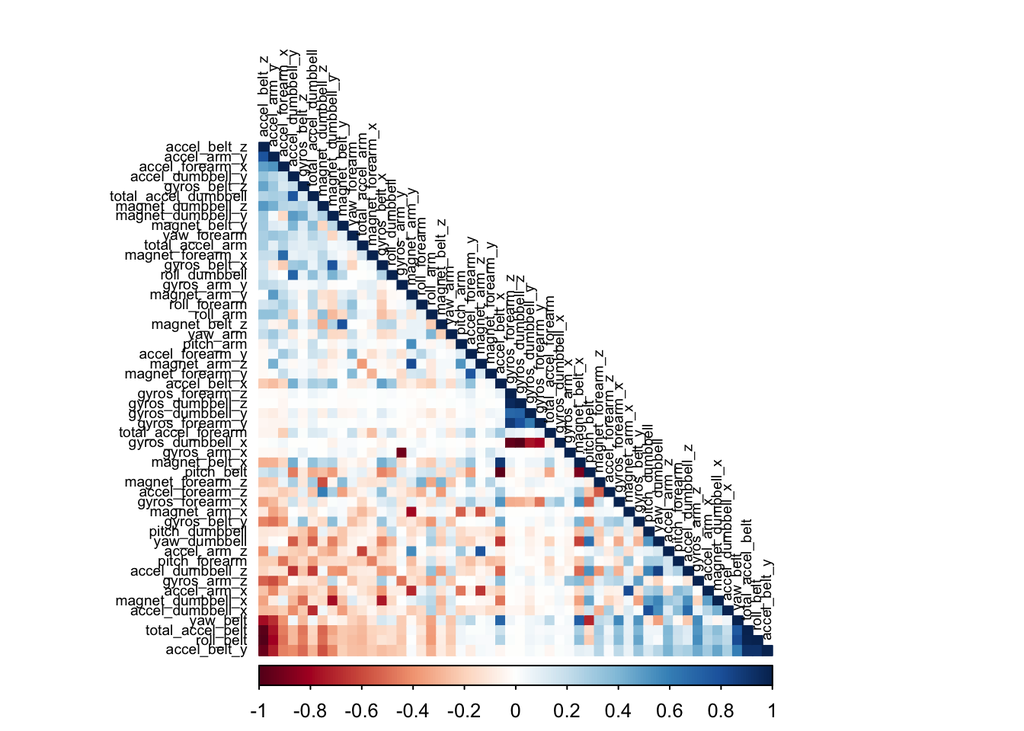

```r
corr_Matrix <- cor(train$train[,-53])

library(corrplot)
corrplot(corr_Matrix,
         order = "FPC",
         method = "color",
         type = "lower",
         tl.cex = 0.6,
         tl.col = rgb(0,0,0)
         )
```

### Model Evaluation

#### Training

Train our Model with Random Forest

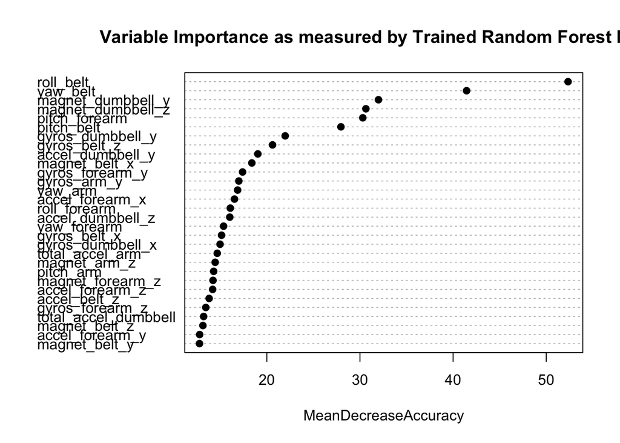

```r
library(randomForest)   #   randomForest:train(), randomForest:trainControl(), randomForest:varImpPlot()
set.seed(12345)
control <- trainControl(method="cv",number=5,classProbs=FALSE, verboseIter=F,preProcOptions="pca",allowParallel=T)

modelFit <- train(classe ~.,
                  method = "rf",
                  data = train$train,
                  trControl = control,
                  ntree = 100,
                  importance = TRUE)

varImpPlot(modelFit$finalModel, sort = TRUE, type = 1, pch = 19, col = 1, cex = 1,
           main = "Variable Importance as measured by Trained Random Forest Model")
```

#### Cross Validation Testing

Apply the fitted RF model to the test partition of the training dataset.

```r
vaildRF <- predict(modelFit, train$test)
confus <- confusionMatrix(train$test$classe, vaildRF)
confus
```

```
## Confusion Matrix and Statistics
##
##           Reference
## Prediction    A    B    C    D    E
##          A 2230    1    1    0    0
##          B   17 1493    8    0    0
##          C    0   11 1352    5    0
##          D    0    1   17 1268    0
##          E    0    4    1    7 1430
##
## Overall Statistics
##
##                Accuracy : 0.9907
##                  95% CI : (0.9883, 0.9927)
##     No Information Rate : 0.2864
##     P-Value [Acc > NIR] : < 2.2e-16
##
##                   Kappa : 0.9882
##  Mcnemar's Test P-Value : NA
##
## Statistics by Class:
##
##                      Class: A Class: B Class: C Class: D Class: E
## Sensitivity            0.9924   0.9887   0.9804   0.9906   1.0000
## Specificity            0.9996   0.9961   0.9975   0.9973   0.9981
## Pos Pred Value         0.9991   0.9835   0.9883   0.9860   0.9917
## Neg Pred Value         0.9970   0.9973   0.9958   0.9982   1.0000
## Prevalence             0.2864   0.1925   0.1758   0.1631   0.1823
## Detection Rate         0.2842   0.1903   0.1723   0.1616   0.1823
## Detection Prevalence   0.2845   0.1935   0.1744   0.1639   0.1838
## Balanced Accuracy      0.9960   0.9924   0.9890   0.9939   0.9991
```

#### Out-of-Sample Error Estimate

```r
accuracy <- postResample(train$test$classe, vaildRF)
model_accuracy <- accuracy[[1]]
model_accuracy
```

```
## [1] 0.9906959
```

```r
out_of_sample_error <- 1 - model_accuracy
out_of_sample_error
```

```
## [1] 0.009304104
```

We find the out of sample error to be incredibly low for this model fit using a random forest which also give support for the use of the model on the final test data set.

### Model Prediction

We now apply the random forest model to our final predicition data set and retrieve the 20 predictions by calling the prediciton final.

```r
finalModel <- predict(modelFit, clean$test)
finalModel
```

```
##  [1] B A B A A E D B A A B C B A E E A B B B
## Levels: A B C D E
```

##### Reference

The data for this project are provided by:

> http://groupware.les.inf.puc-rio.br/har

*See the section, “Weight Lifting Exercise Dataset” for more details.*